# A3.2 Redes Neuronales

```
1500/1500 ━━━━━━━━━━━━━━━━━━━━ 8s 4ms/step - accuracy: 0.8597 - loss: 0.4779 - val_accuracy: 0.9541 - val_loss: 0.1474
1500/1500 ━━━━━━━━━━━━━━━━━━━━ 4s 3ms/step - accuracy: 0.9664 - loss: 0.1136 - val_accuracy: 0.9649 - val_loss: 0.1129
1500/1500 ━━━━━━━━━━━━━━━━━━━━ 6s 3ms/step - accuracy: 0.9778 - loss: 0.0726 - val_accuracy: 0.9709 - val_loss: 0.0946
1500/1500 ━━━━━━━━━━━━━━━━━━━━ 4s 3ms/step - accuracy: 0.9835 - loss: 0.0547 - val_accuracy: 0.9663 - val_loss: 0.1085
1500/1500 ━━━━━━━━━━━━━━━━━━━━ 5s 3ms/step - accuracy: 0.9856 - loss: 0.0457 - val_accuracy: 0.9728 - val_loss: 0.0960
1500/1500 ━━━━━━━━━━━━━━━━━━━━ 6s 4ms/step - accuracy: 0.9903 - loss: 0.0313 - val_accuracy: 0.9742 - val_loss: 0.0994
1500/1500 ━━━━━━━━━━━━━━━━━━━━ 4s 3ms/step - accuracy: 0.9913 - loss: 0.0262 - val_accuracy: 0.9737 - val_loss: 0.0995
1500/1500 ━━━━━━━━━━━━━━━━━━━━ 5s 3ms/step - accuracy: 0.9920 - loss: 0.0239 - val_accuracy: 0.9741 - val_loss: 0.1046
1500/1500 ━━━━━━━━━━━━━━━━━━━━ 5s 3ms/step - accuracy: 0.9946 - loss: 0.0180 - val_accuracy: 0.9732 - val_loss: 0.1173
1500/1500 ━━━━━━━━━━━━━━━━━━━━ 4s 3ms/step - accuracy: 0.9938 - loss: 0.0176 - val_accuracy: 0.9731 - val_loss: 0.1238
1500/1500 ━━━━━━━━━━━━━━━━━━━━ 6s 3ms/step - accuracy: 0.9954 - loss: 0.0146 - val_accuracy: 0.9737 - val_loss: 0.1195
1500/1500 ━━━━━━━━━━━━━━━━━━━━ 5s 3ms/step - accuracy: 0.9953 - loss: 0.0137 - val_accuracy: 0.9768 - val_loss: 0.1130
1500/1500 ━━━━━━━━━━━━━━━━━━━━ 5s 3ms/step - accuracy: 0.9963 - loss: 0.0120 - val_accuracy: 0.9725 - val_loss: 0.1313
1500/1500 ━━━━━━━━━━━━━━━━━━━━ 4s 3ms/step - accuracy: 0.9957 - loss: 0.0124 - val_accuracy: 0.9745 - val_loss: 0.1219
1500/1500 ━━━━━━━━━━━━━━━━━━━━ 5s 3ms/step - accuracy: 0.9962 - loss: 0.0131 - val_accuracy: 0.9762 - val_loss: 0.1262
1500/1500 ━━━━━━━━━━━━━━━━━━━━ 5s 3ms/step - accuracy: 0.9969 - loss: 0.0101 - val_accuracy: 0.9743 - val_loss: 0.1460
1500/1500 ━━━━━━━━━━━━━━━━━━━━ 5s 3ms/step - accuracy: 0.9963 - loss: 0.0108 - val_accuracy: 0.9768 - val_loss: 0.1299
1500/1500 ━━━━━━━━━━━━━━━━━━━━ 5s 3ms/step - accuracy: 0.9970 - loss: 0.0097 - val_accuracy: 0.9755 - val_loss: 0.1347
1500/1500 ━━━━━━━━━━━━━━━━━━━━ 4s 3ms/step - accuracy: 0.9964 - loss: 0.0107 - val_accuracy: 0.9754 - val_loss: 0.1537
1500/1500 ━━━━━━━━━━━━━━━━━━━━ 5s 3ms/step - accuracy: 0.9971 - loss: 0.0082 - val_accuracy: 0.9738 - val_loss: 0.1540
1500/1500 ━━━━━━━━━━━━━━━━━━━━ 5s 3ms/step - accuracy: 0.9970 - loss: 0.0110 - val_accuracy: 0.9738 - val_loss: 0.1670
1500/1500 ━━━━━━━━━━━━━━━━━━━━ 4s 3ms/step - accuracy: 0.9966 - loss: 0.0091 - val_accuracy: 0.9776 - val_loss: 0.1392
1500/1500 ━━━━━━━━━━━━━━━━━━━━ 5s 3ms/step - accuracy: 0.9981 - loss: 0.0063 - val_accuracy: 0.9779 - val_loss: 0.1438
1500/1500 ━━━━━━━━━━━━━━━━━━━━ 6s 3ms/step - accuracy: 0.9978 - loss: 0.0062 - val_accuracy: 0.9759 - val_loss: 0.1586
1500/1500 ━━━━━━━━━━━━━━━━━━━━ 5s 3ms/step - accuracy: 0.9972 - loss: 0.0085 - val_accuracy: 0.9764 - val_loss: 0.1467
1500/1500 ━━━━━━━━━━━━━━━━━━━━ 5s 3ms/step - accuracy: 0.9979 - loss: 0.0062 - val_accuracy: 0.9769 - val_loss: 0.1676
1500/1500 ━━━━━━━━━━━━━━━━━━━━ 4s 3ms/step - accuracy: 0.9985 - loss: 0.0050 - val_accuracy: 0.9761 - val_loss: 0.1677
1500/1500 ━━━━━━━━━━━━━━━━━━━━ 5s 3ms/step - accuracy: 0.9984 - loss: 0.0055 - val_accuracy: 0.9755 - val_loss: 0.1806
1500/1500 ━━━━━━━━━━━━━━━━━━━━ 6s 3ms/step - accuracy: 0.9974 - loss: 0.0083 - val_accuracy: 0.9760 - val_loss: 0.1654
1500/1500 ━━━━━━━━━━━━━━━━━━━━ 5s 3ms/step - accuracy: 0.9973 - loss: 0.0086 - val_accuracy: 0.9762 - val_loss: 0.1661
1500/1500 ━━━━━━━━━━━━━━━━━━━━ 5s 3ms/step - accuracy: 0.9977 - loss: 0.0064 - val_accuracy: 0.9785 - val_loss: 0.1588
1500/1500 ━━━━━━━━━━━━━━━━━━━━ 4s 3ms/step - accuracy: 0.9997 - loss: 0.0016 - val_accuracy: 0.9688 - val_loss: 0.2307
1500/1500 ━━━━━━━━━━━━━━━━━━━━ 4s 3ms/step - accuracy: 0.9975 - loss: 0.0080 - val_accuracy: 0.9759 - val_loss: 0.1842
1500/1500 ━━━━━━━━━━━━━━━━━━━━ 5s 3ms/step - accuracy: 0.9986 - loss: 0.0048 - val_accuracy: 0.9771 - val_loss: 0.1757
1500/1500 ━━━━━━━━━━━━━━━━━━━━ 10s 3ms/step - accuracy: 0.9985 - loss: 0.0043 - val_accuracy: 0.9762 - val_loss: 0.1801
1500/1500 ━━━━━━━━━━━━━━━━━━━━ 4s 3ms/step - accuracy: 0.9987 - loss: 0.0046 - val_accuracy: 0.9757 - val_loss: 0.1879
1500/1500 ━━━━━━━━━━━━━━━━━━━━ 6s 3ms/step - accuracy: 0.9972 - loss: 0.0093 - val_accuracy: 0.9773 - val_loss: 0.1940
1500/1500 ━━━━━━━━━━━━━━━━━━━━ 6s 3ms/step - accuracy: 0.9981 - loss: 0.0063 - val_accuracy: 0.9774 - val_loss: 0.1758
1500/1500 ━━━━━━━━━━━━━━━━━━━━ 5s 3ms/step - accuracy: 0.9990 - loss: 0.0036 - val_accuracy: 0.9736 - val_loss: 0.2061
1500/1500 ━━━━━━━━━━━━━━━━━━━━ 5s 3ms/step - accuracy: 0.9981 - loss: 0.0061 - val_accuracy: 0.9762 - val_loss: 0.1996
1500/1500 ━━━━━━━━━━━━━━━━━━━━ 5s 3ms/step - accuracy: 0.9988 - loss: 0.0040 - val_accuracy: 0.9768 - val_loss: 0.2176
313/313 ━━━━━━━━━━━━━━━━━━━━ 1s 3ms/step - accuracy: 0.9758 - loss: 0.1601
Exactitud final en entrenamiento: 0.9985
Exactitud final en validación: 0.9768

Exactitud en datos de prueba: 0.9802
```

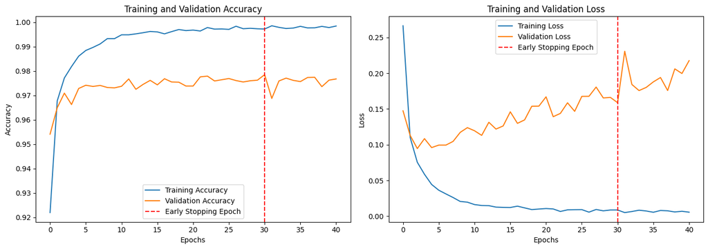

```python
from tensorflow.keras.models import Sequential
from tensorflow.keras.layers import Dense, Flatten
from tensorflow.keras.utils import to_categorical
from tensorflow.keras.callbacks import EarlyStopping
from matplotlib.ticker import MaxNLocator

# Normalizar imágenes
x_train = x_train / 255
x_test = x_test / 255

# Convertir etiquetas a one-hot encoding
y_train_cat = to_categorical(y_train, 10)
y_test_cat = to_categorical(y_test, 10)

# Crear el modelo
model = Sequential([
    Flatten(input_shape=(28, 28)),
    Dense(128, activation='relu'),
    Dense(64, activation='relu'),
    Dense(10, activation='softmax')
])

# Compilar el modelo
model.compile(optimizer='adam', loss='categorical_crossentropy', metrics=['accuracy'])

# Crear un early stopping callback
early_stop = EarlyStopping(monitor='val_accuracy', patience=10, restore_best_weights=True)

# Entrenar el modelo
history = model.fit(x_train, y_train_cat, epochs=50, batch_size=32, validation_split=0.2, callbacks=[early_stop], verbose=1)

# Evaluar en datos de prueba
test_loss, test_acc = model.evaluate(x_test, y_test_cat)
print(f"Exactitud final en entrenamiento: {history.history['accuracy'][-1]:.4f}")
print(f"Exactitud final en validación: {history.history['val_accuracy'][-1]:.4f}")
print(f"\nExactitud en datos de prueba: {test_acc:.4f}")

# Graficar pérdida y exactitud durante el entrenamiento
plt.figure(figsize=(14, 5))

stopped_epoch = early_stop.stopped_epoch
best_epoch = stopped_epoch - early_stop.patience

# Exactitud
plt.subplot(1, 2, 1)
plt.plot(history.history['accuracy'], label='Training Accuracy')
plt.plot(history.history['val_accuracy'], label='Validation Accuracy')
plt.axvline(x=best_epoch, color='r', linestyle='--', label='Early Stopping Epoch')
plt.title('Training and Validation Accuracy')
plt.xlabel('Epochs')
plt.ylabel('Accuracy')
plt.gca().xaxis.set_major_locator(MaxNLocator(integer=True))
plt.legend()

# Pérdida
plt.subplot(1, 2, 2)
plt.plot(history.history['loss'], label='Training Loss')
plt.plot(history.history['val_loss'], label='Validation Loss')
plt.axvline(x=best_epoch, color='r', linestyle='--', label='Early Stopping Epoch')
plt.title('Training and Validation Loss')
plt.xlabel('Epochs')
plt.ylabel('Loss')
plt.gca().xaxis.set_major_locator(MaxNLocator(integer=True))
plt.legend()

plt.tight_layout()
plt.show()
```

2. Se evalúa la exactitud del modelo en el conjunto de prueba generado al cargar la base de datos y se compara con la exactitud de validación del modelo.

Los resultados obtenidos fueron los siguientes:

| **Métrica** | **Resultado** |
| --- | --- |
| Exactitud en validación | 0.9768 |
| Exactitud en prueba | 0.9802 |
| Diferencia | 0.0034 |

3. Se generan 50 imágenes, 5 para cada dígito, preprocesandolas para que puedan ser evaluadas por el modelo.
- Seleccionar las imágenes

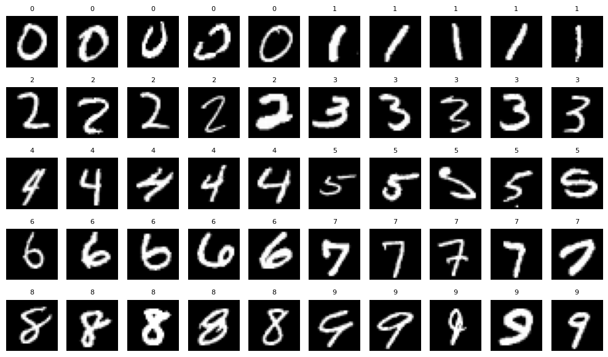

```python
# Seleccionar 5 imagenes por cada digito
imagenes_seleccionadas = []
etiquetas_seleccionadas = []

for digito in range(10):
    idxs = np.where(y_test == digito)[0]
    seleccionados = np.random.choice(idxs, size=5, replace=False)  # Selección aleatoria sin reemplazo
    imagenes_seleccionadas.extend(x_test[seleccionados])
    etiquetas_seleccionadas.extend(y_test[seleccionados])

imagenes_seleccionadas = np.array(imagenes_seleccionadas)
etiquetas_seleccionadas = np.array(etiquetas_seleccionadas)

# Mostrar las imágenes seleccionadas
plt.figure(figsize=(10, 6))
for i in range(50):
  plt.subplot(5, 10, i+1)
  plt.imshow(imagenes_seleccionadas[i], cmap='gray')
  plt.axis('off')
  plt.title(str(etiquetas_seleccionadas[i]), fontsize=8)
plt.tight_layout()
plt.show()
```

4. Evaluar el modelo con las imágenes, comparando los resultados con los previos y comentando motivos de potencial error.

```python
predicciones = model.predict(imagenes_seleccionadas)
clases_predichas = np.argmax(predicciones, axis=1)

# Mostrar resultados
for i in range(50):
  print(f"Imagen {i+1}: \nEtiqueta real = {etiquetas_seleccionadas[i]}\nPredicción = {clases_predichas[i]}")
```

```
2/2 ━━━━━━━━━━━━━━━━━━━━ 1s 526ms/step
Imagen 1:
Etiqueta real = 0
Predicción = 0
Imagen 2:
Etiqueta real = 0
Predicción = 0
Imagen 3:
Etiqueta real = 0
Predicción = 0
Imagen 4:
Etiqueta real = 0
Predicción = 0
Imagen 5:
Etiqueta real = 0
Predicción = 0
Imagen 6:
Etiqueta real = 1
Predicción = 1
Imagen 7:
Etiqueta real = 1
Predicción = 1
Imagen 8:
Etiqueta real = 1
Predicción = 1
Imagen 9:
Etiqueta real = 1
Predicción = 1
Imagen 10:
Etiqueta real = 1
Predicción = 1
Imagen 11:
Etiqueta real = 2
Predicción = 2
Imagen 12:
Etiqueta real = 2
Predicción = 2
Imagen 13:
Etiqueta real = 2
Predicción = 2
```

[output cut: 96 more lines]

```
Imagen 46:
Etiqueta real = 9
Predicción = 9
Imagen 47:
Etiqueta real = 9
Predicción = 9
Imagen 48:
Etiqueta real = 9
Predicción = 9
Imagen 49:
Etiqueta real = 9
Predicción = 9
Imagen 50:
Etiqueta real = 9
Predicción = 9
```

- Calcular la exactitud.

```python
exactitud_50 = np.mean(clases_predichas == etiquetas_seleccionadas)
print(f"Exactitud en las 50 imágenes seleccionadas: {exactitud_50:.4f}")
```

```
Exactitud en las 50 imágenes seleccionadas: 0.9600
```

5. Se generan 3 mejoras, innovaciones o adiciones al sistema actual.
- Se implementa un aumento de datos en la fase de entrenamiento incorporando una capa de ImageDataGenerator para generar versiones variadas de las imágenes originales. Esto permite que el modelo vea más variabilidad de escritura, generalizando mejor a nuevas formas de escribir los dígitos.

```
750/750 ━━━━━━━━━━━━━━━━━━━━ 16s 20ms/step - accuracy: 0.6944 - loss: 0.9820 - val_accuracy: 0.9454 - val_loss: 0.1931
750/750 ━━━━━━━━━━━━━━━━━━━━ 14s 19ms/step - accuracy: 0.9183 - loss: 0.2739 - val_accuracy: 0.9558 - val_loss: 0.1442
750/750 ━━━━━━━━━━━━━━━━━━━━ 21s 19ms/step - accuracy: 0.9372 - loss: 0.2099 - val_accuracy: 0.9624 - val_loss: 0.1166
750/750 ━━━━━━━━━━━━━━━━━━━━ 14s 19ms/step - accuracy: 0.9438 - loss: 0.1861 - val_accuracy: 0.9671 - val_loss: 0.1019
750/750 ━━━━━━━━━━━━━━━━━━━━ 16s 22ms/step - accuracy: 0.9475 - loss: 0.1722 - val_accuracy: 0.9676 - val_loss: 0.1038
750/750 ━━━━━━━━━━━━━━━━━━━━ 19s 20ms/step - accuracy: 0.9525 - loss: 0.1547 - val_accuracy: 0.9709 - val_loss: 0.0922
750/750 ━━━━━━━━━━━━━━━━━━━━ 15s 19ms/step - accuracy: 0.9550 - loss: 0.1467 - val_accuracy: 0.9732 - val_loss: 0.0884
750/750 ━━━━━━━━━━━━━━━━━━━━ 20s 19ms/step - accuracy: 0.9568 - loss: 0.1409 - val_accuracy: 0.9722 - val_loss: 0.0912
750/750 ━━━━━━━━━━━━━━━━━━━━ 15s 20ms/step - accuracy: 0.9585 - loss: 0.1345 - val_accuracy: 0.9737 - val_loss: 0.0877
750/750 ━━━━━━━━━━━━━━━━━━━━ 16s 21ms/step - accuracy: 0.9623 - loss: 0.1236 - val_accuracy: 0.9777 - val_loss: 0.0758
750/750 ━━━━━━━━━━━━━━━━━━━━ 20s 20ms/step - accuracy: 0.9641 - loss: 0.1171 - val_accuracy: 0.9785 - val_loss: 0.0732
750/750 ━━━━━━━━━━━━━━━━━━━━ 20s 19ms/step - accuracy: 0.9650 - loss: 0.1118 - val_accuracy: 0.9772 - val_loss: 0.0714
750/750 ━━━━━━━━━━━━━━━━━━━━ 21s 20ms/step - accuracy: 0.9689 - loss: 0.1027 - val_accuracy: 0.9775 - val_loss: 0.0727
750/750 ━━━━━━━━━━━━━━━━━━━━ 14s 19ms/step - accuracy: 0.9667 - loss: 0.1080 - val_accuracy: 0.9793 - val_loss: 0.0686
750/750 ━━━━━━━━━━━━━━━━━━━━ 15s 20ms/step - accuracy: 0.9683 - loss: 0.1058 - val_accuracy: 0.9776 - val_loss: 0.0732
750/750 ━━━━━━━━━━━━━━━━━━━━ 15s 21ms/step - accuracy: 0.9692 - loss: 0.1022 - val_accuracy: 0.9781 - val_loss: 0.0711
750/750 ━━━━━━━━━━━━━━━━━━━━ 19s 19ms/step - accuracy: 0.9688 - loss: 0.0998 - val_accuracy: 0.9800 - val_loss: 0.0641
750/750 ━━━━━━━━━━━━━━━━━━━━ 15s 20ms/step - accuracy: 0.9704 - loss: 0.0978 - val_accuracy: 0.9820 - val_loss: 0.0621
750/750 ━━━━━━━━━━━━━━━━━━━━ 15s 20ms/step - accuracy: 0.9704 - loss: 0.0970 - val_accuracy: 0.9809 - val_loss: 0.0648
750/750 ━━━━━━━━━━━━━━━━━━━━ 20s 20ms/step - accuracy: 0.9721 - loss: 0.0908 - val_accuracy: 0.9818 - val_loss: 0.0597
313/313 ━━━━━━━━━━━━━━━━━━━━ 1s 3ms/step - accuracy: 0.9774 - loss: 0.0651
Exactitud final en entrenamiento: 0.9717
Exactitud final en validación: 0.9818

Exactitud en datos de prueba: 0.9798
```

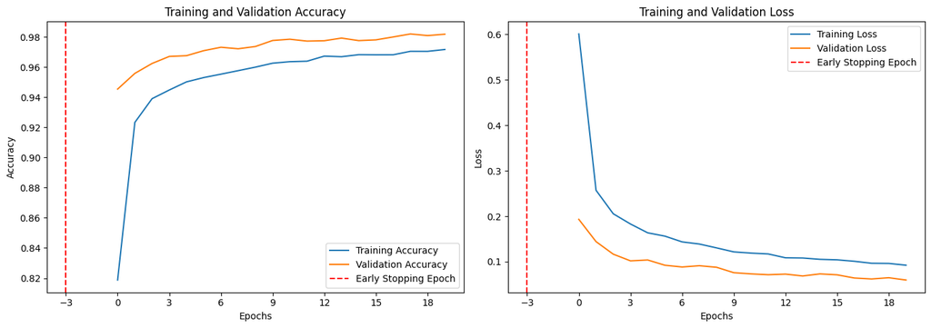

```python
from tensorflow.keras.preprocessing.image import ImageDataGenerator
from sklearn.model_selection import train_test_split

# Preprocesamiento y expansión del canal
x_train_expanded = x_train.reshape(-1, 28, 28, 1)
x_test_expanded = x_test.reshape(-1, 28, 28, 1)

# Separar entrenamiento y validación manualmente
x_train_part, x_val, y_train_part, y_val = train_test_split(
    x_train_expanded, y_train_cat, test_size=0.2, random_state=42
)

# Definir generador con data augmentation
datagen = ImageDataGenerator(
    rotation_range=10,
    zoom_range=0.1,
    width_shift_range=0.1,
    height_shift_range=0.1
)

datagen.fit(x_train_part)

# Volver a crear el modelo
model2 = Sequential([
    Flatten(input_shape=(28, 28, 1)),
    Dense(128, activation='relu'),
    Dense(64, activation='relu'),
    Dense(10, activation='softmax')
])

model2.compile(optimizer='adam', loss='categorical_crossentropy', metrics=['accuracy'])

# EarlyStopping
early_stop = EarlyStopping(monitor='val_loss', patience=3, restore_best_weights=True)

# Volver a entrenar usando data augmentation
batch_size = 64
epochs = 20

history = model2.fit(
    datagen.flow(x_train_part, y_train_part, batch_size=batch_size),
    epochs=epochs,
    validation_data=(x_val, y_val),
    steps_per_epoch=len(x_train_part) // batch_size,
    callbacks=[early_stop],
    verbose=1
)

# Evaluar en datos de prueba
test_loss, test_acc = model2.evaluate(x_test_expanded, y_test_cat)
print(f"Exactitud final en entrenamiento: {history.history['accuracy'][-1]:.4f}")
print(f"Exactitud final en validación: {history.history['val_accuracy'][-1]:.4f}")
print(f"\nExactitud en datos de prueba: {test_acc:.4f}")

# Graficar pérdida y exactitud durante el entrenamiento
plt.figure(figsize=(14, 5))

stopped_epoch = early_stop.stopped_epoch
best_epoch = stopped_epoch - early_stop.patience

# Exactitud
plt.subplot(1, 2, 1)
plt.plot(history.history['accuracy'], label='Training Accuracy')
plt.plot(history.history['val_accuracy'], label='Validation Accuracy')
plt.axvline(x=best_epoch, color='r', linestyle='--', label='Early Stopping Epoch')
plt.title('Training and Validation Accuracy')
plt.xlabel('Epochs')
plt.ylabel('Accuracy')
plt.gca().xaxis.set_major_locator(MaxNLocator(integer=True))
plt.legend()

# Pérdida
plt.subplot(1, 2, 2)
plt.plot(history.history['loss'], label='Training Loss')
plt.plot(history.history['val_loss'], label='Validation Loss')
plt.axvline(x=best_epoch, color='r', linestyle='--', label='Early Stopping Epoch')
plt.title('Training and Validation Loss')
plt.xlabel('Epochs')
plt.ylabel('Loss')
plt.gca().xaxis.set_major_locator(MaxNLocator(integer=True))
plt.legend()

plt.tight_layout()
plt.show()
```

- Probar el nuevo modelo con las imágenes seleccionadas anteriormente.

```python
predicciones2 = model2.predict(imagenes_seleccionadas)
clases_predichas2 = np.argmax(predicciones2, axis=1)

# Mostrar resultados
for i in range(50):
  print(f"Imagen {i+1}: \nEtiqueta real = {etiquetas_seleccionadas[i]}\nPredicción = {clases_predichas2[i]}")
```

```
2/2 ━━━━━━━━━━━━━━━━━━━━ 0s 146ms/step
Imagen 1:
Etiqueta real = 0
Predicción = 0
Imagen 2:
Etiqueta real = 0
Predicción = 0
Imagen 3:
Etiqueta real = 0
Predicción = 4
Imagen 4:
Etiqueta real = 0
Predicción = 0
Imagen 5:
Etiqueta real = 0
Predicción = 0
Imagen 6:
Etiqueta real = 1
Predicción = 1
Imagen 7:
Etiqueta real = 1
Predicción = 1
Imagen 8:
Etiqueta real = 1
Predicción = 1
Imagen 9:
Etiqueta real = 1
Predicción = 1
Imagen 10:
Etiqueta real = 1
Predicción = 1
Imagen 11:
Etiqueta real = 2
Predicción = 2
Imagen 12:
Etiqueta real = 2
Predicción = 2
Imagen 13:
Etiqueta real = 2
Predicción = 2
```

[output cut: 96 more lines]

```
Imagen 46:
Etiqueta real = 9
Predicción = 9
Imagen 47:
Etiqueta real = 9
Predicción = 9
Imagen 48:
Etiqueta real = 9
Predicción = 9
Imagen 49:
Etiqueta real = 9
Predicción = 9
Imagen 50:
Etiqueta real = 9
Predicción = 9
```

- Calcular la exactitud del nuevo modelo con las imágenes seleccionadas.

```python
exactitud_50_2 = np.mean(clases_predichas2 == etiquetas_seleccionadas)
print(f"Exactitud en las 50 imágenes seleccionadas: {exactitud_50_2:.4f}")
```

```
Exactitud en las 50 imágenes seleccionadas: 0.9600
```

- Se implementa una herramienta visual que muestra solo las imágenes mal clasificadas junto con sus etiquetas reales y predicas. Aunque esto no mejora el modelo directamente como tal, si permite al usuario detectar patrones en los errores, como confusiones sistemáticas entre ciertos dígitos o mala calidad de la imágen y realizar decisiones informadas como: ajustar el modelo, revisar los datos o implementar una red más compleja.

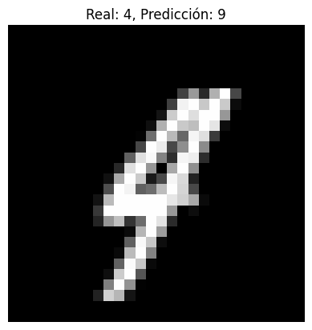

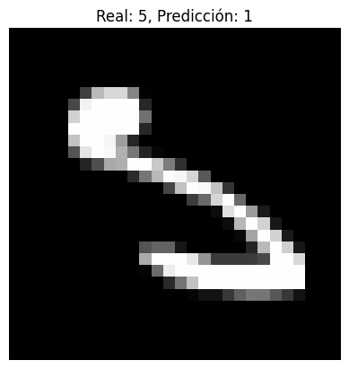

```python
errores = np.where(clases_predichas != etiquetas_seleccionadas)[0]

for i in errores:
  plt.imshow(imagenes_seleccionadas[i], cmap='gray')
  plt.title(f"Real: {etiquetas_seleccionadas[i]}, Predicción: {clases_predichas[i]}")
  plt.axis('off')
  plt.show()
```

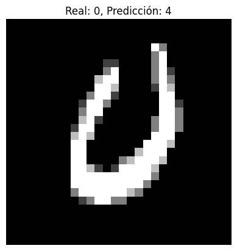

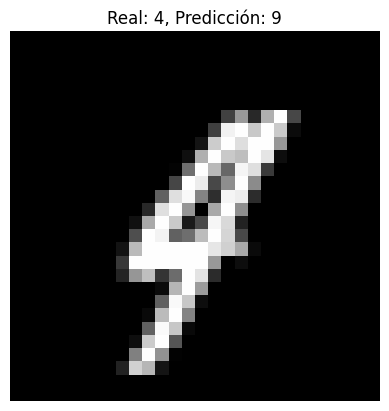

```python
errores2 = np.where(clases_predichas2 != etiquetas_seleccionadas)[0]

for i in errores2:
  plt.imshow(imagenes_seleccionadas[i], cmap='gray')
  plt.title(f"Real: {etiquetas_seleccionadas[i]}, Predicción: {clases_predichas2[i]}")
  plt.axis('off')
  plt.show()
```

En los errores detectados se observan imágenes de números que están gráficamente deformes siguiendo patrones que no son los convencionales para ayudar al modelo para identificar el número que realmente es, confundiéndolo con otros números como es el 4 que parece 9 debido a sus lineas cerradas y la falta de claridad en las intersecciones o el cero que no tiene el círculo cerrado, pudiendo crear confusión en el modelo específicamente si las imágenes con las que se entrenó para el número no incluyen círculos tan incompletos como el que se muestra en la imagen.

- Implementar guardado del modelo y carga posterior para evitar la necesidad de reentrenarlo desde cero cada vez y así reutilizarlo para hacer otras predicciones en otros entornos.

```python
model.save("modelo_mnist.h5")
model2.save("modelo2_mnist.h5")

# Código para cargar en otro script
# from tensorflow.keras.models import load_model
# model = load_model("modelo_mnist.h5")
```

```
WARNING:absl:You are saving your model as an HDF5 file via `model.save()` or `keras.saving.save_model(model)`. This file format is considered legacy. We recommend using instead the native Keras format, e.g. `model.save('my_model.keras')` or `keras.saving.save_model(model, 'my_model.keras')`.
WARNING:absl:You are saving your model as an HDF5 file via `model.save()` or `keras.saving.save_model(model)`. This file format is considered legacy. We recommend using instead the native Keras format, e.g. `model.save('my_model.keras')` or `keras.saving.save_model(model, 'my_model.keras')`.
```

6. Se genera un sistema que prediga en tiempo real los dígitos del 0 al 9 a partir de la imagen capturada por la cámara de la computadora.
- **Link del video**: https://drive.google.com/file/d/1oWP_xzhJwnHPM6h7dXORvCgEr26QGuY9/view?usp=sharing
- Como se puede observar en el video, el sistema de captura y predicción de dígitos en tiempo real trata de identificar los dígittos del 1 al 9 escritos en un lienzo digital. Identificó correctamente 6 dígitos de los 9 que se le mostraron, los cuales fueron: [2, 3, 5, 6, 8, 9].
- Los tres dígitos restantes [1, 4, 7], fueron confundidos por los dígitos [3, 9, 3].
- 5 de las 9 predicciones tienen confianza alta, lo que sugiere que más de la mitad de los datos proporcionados si son de buena calidad y fueron claros para el modelo aunque algunos no fueron correctamente identificados.
- Las otras 4 predicciones tuvieron confianza baja, lo que puede significar problemas con los patrones o el tipo de escritura poco común para el modelo de esos números proporcionados.
- La tasa de precisión (accuracy) calculada en base a estos datos es de 66.7%.